# Pre-registration_Geomphon_hindi

Amelia

01/10/2019

# Letter

The process of perception of an unfamiliar speech sound is theorized to involve a comparison of the unfamiliar sound to representations of familiar sounds, that is sounds that have been heard repeatedly in the past. However, research testing the ability to discriminate an unfamiliar sound often focuses on the difference betweeen the unfamiliar sound and the one familiar sound that is determined to be the “nearest” sound in perceptual or acoustic space. This narrow focus on the one nearest sound ignores the rest of a large and often crowded represetation space.

This is important because it is known that sound inventories of language are not random in their geometric shape, but instead can be measured to have global and local symmetry and economy, above and beyond what would be expected by chance. (Dunbar & Dupoux 2016). We ask: does the shape of the entire sound inventory affect discirmination of an unfamiliar sound, above and beyond the effect of distance to the nearest sound? Our research has implications for theories of language change and second language acquisition and practical applications in language teaching.

The study has been approved by the Comité d’Éthique de la Recherche of Université Paris Decartes as of June 13, 2019. All funding for participant payment is covered by the Agence National de Récherche grant numbers ANR-17-CE28-0009 (GEOMPHON) and ANR-10-LABX-0083 (EFL). Web hosting for the online studies will be provided by the Laboratoire de Linguistique Formelle. The study is ready to commence immediately.

Data collection for the English speakers will take a maximum of one week to complete. Based on previous studies we expect recruitment of French participants will take longer, but we anticipate being able to run all participants within a two week window. Once data is collected all code is in place to immediately run models and create vizualizations. At this point we will take one further week to move from a stage 1 manuscript to a stage 2 manuscript. The total time anticipated to go from in principle approval to stage 2 manuscript is one month.

We agree to participate in the Open Peer Review system.

Following Stage 1 in principle acceptance, we agree to register the approved protocol on the Open Science Framework either publicly or under private embargo until submission of the Stage 2 manuscript.

If we should withdraw the paper following in principle acceptance, we agree to the publicaiton of a short summary of the pre-registered study as a Withdrawn Registration.

appropriate reviewers with expertise in linguistics and Bayesian Methods include:

Jeff Mielke  
Timo Roettger  
Bodo Winter  
Till Poppels

# Introduction

### background

Over a lifetime of speech perception, humans fine-tune their sensitivity to phonetic differences that are contrastive in their native language. When listeners hear a new phone, be it a phone from a new language or a variant they have not previously encountered, they are faced with the task of perceiving new sounds with a perceptual system that is tuned to their native language and dialect. There is extensive research investigating precisely how this is accomplished. In formal models of language learning such as the Speech Learning Model (Flege) and the Perceptual Assimilation Model (Best,1995, Best & Tyler 2007), an important concept that has arisen from past work is the distance of the unfamiliar sound to the nearest familiar sound in the native inventory. Unfamiliar sounds will be hard to discriminate from a familiar sound that is close, and easier to discriminate from a familiar sound that is farther away.

What makes two sounds “close” or “far away” is defined in different ways: principally, as either an objective acoustic distance measured on some element of an acoustic signal, or as a perceptual distance which can be measured through discrimination tasks. However, a narrow focus on the distance between one familiar sound and one unfamiliar sound ignores the crucial fact that phonetic space is crowded for most sound inventories. If we consider representations in a continous acoustic space, an unfamiliar sound which is “far” from one familar sound may also be “near” to other sounds. A familiar example is to look at the vowel space, mapped by the first formant vs second formant. The inventory of Spanish has five vowels (below, in black), and when vizualized in an f1 vs f2 they show somewhat even spacing, and a symmetrical distribution. Let us imagine a Spanish speaker who is encountering French sounds for the first time and is attempting to add them to their mental representation. Some french sounds will be very similar acoustically to sounds already exsisting in their inventory, and some will be very different. Also, adding a new sound to their already established inventory of sounds will also change the arrangement of sounds in the inventory. In the case of the added sounds here (in red, below),both /y/ and /ɛ/ have a similar distance to the nearest sounds in the native inventory. However, adding /ɛ/ increases the symmetry of the system and creates an inventory with similar distance between each sound, whereas adding /y/ creates an inventory that is unbalanced, has less symmetry, and has greater variation in the distances between sounds.

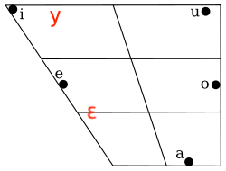

This leads us to the question: Is accuracy in discriminating a new sound principally driven by acoustic distance to the nearest sound in the native inventory? Or does the change in shape of the inventory also play a role?

We follow this line of inquiry because of previous work indicating that sound inventories are not random in their distribution of sounds (Dunbar & Dupoux 2016). Dunpar & Doupoux (2016) develop three measurements which encompass these tendencies:

1. economy (“Econ”): if two inventories have the same number of sounds, those sounds tend, all things being equal, to require relatively few features to characterize.
2. local symmetry (“Loc”) : if two inventories have the same number of sounds, using the same number of features, those sounds tend to make relatively many “minimal oppositions” between pairs of sounds, which differ only in one feature.
3. global symmetry (“Glob”): if two inventories are matched geometrically on the other two properties, they tend to have sounds that are more symmetrically distributed.

Because these metrics measure the geometry of an entire inventory, we call these measures “geomphon scores.” Unlike the toy example above displaying an inventory in a continuous f1-f2 space, these scores are based on discrete discrete phonological features, and visualise inventories as n-dimensional hypercubes. This allows the scores to take into account far more features than the simple two-dimensional diagram above. Details of the precise method are available in Dunbar & Dupoux (2016). While Dunbar & Dupoux establish that sound inventories of the worlds languages maximize these properties above and beyond the distribution expected by chance, they do not establish *why* inventories maximize these scores. One possible reason is that inventories that maximize these scores are optimal for discrimination of sounds within an inventory. This would lead to the prediction that a change in inventory that reduces one of these scores would lead to worse discrimination, when compared to a change in inventory that increases one of these scores.

The motivation for this experiment is to test whether the spatial relation of all the sounds in a phoneme inventory affect perception of a given unafamiliar sound. Specifically, we test whether changes in geomphon scores are predictive of discrimination accuracy, above and beyond the effect of acoustic distance to one nearest sound.

To accomplish this we collect discrimination data from an ABX task. That is, listeners hear one sound (“A”), then another sound (“B”“), and then a new instance of one of the previously heard sounds (”X“). Each AB pair of sounds includes one sound that is familiar (= part of the native inventory of participants), and one sound that is unfamiliar (= not part of the native inventory of participants). For each pair of sounds, we calculate the acoustic distance between sounds, and also the change in geomphon scores if the unfamiliar sound were added to the native inventory. (see more detail in #Method, below) In brief, our hypotheses are as follows:

### Hypothesiss

We hypothesize that changes in Econ, Glob, and Loc will each be predictive of discimination accuracy, above and beyond the effect of acoustic distance.

### Predictions and operationalization of hypotheses

Predictions

1. For each trial with sounds A, B, and X(an instance of either A or B), we will measure the acoustic distance between A and X, and between B and X. If these distances are similar, we predict the task will be hard because this indicates that X is similar to both A and B. If, however, one of the distances is much greater than the other, it will be obvious which sound X is an instance of, and the task will be easy. In short, we predict that the larger the difference between the measured distances (A->X) and (B->X), the higher the discrimination accuracy will be.
2. Each trial ABX will have one unfamiliar sound. Each unfamiliar sound will be given a value for how much it would change geomphon scores if it were added to the native inventory. We expect that the more a sound would cause a negative change in a geomphon score, the lower the discrimination accuracy for that sound will be.

this will be operationalized as a generalized linear model with a logistic link function. The dependent variable will be participant accuracy. The predictors of interest will be the change in each of the geomphon scores, and the difference in acoustic distances for the two sounds in each trial. We expect the effect will vary by subject and by item and so we intend to include random effects in the model for subject and for item. In lme4() syntax, the model would be written as follows:

Accuracy ~ Change_in_econ + Change_in_glob + Change_in_loc + difference_between_acoustic_distances + (1 + Econ+glob + Loc + acoustic_distance|subject) + (1|item)

# Method

summary of method: (more details below) The experiment is presented via an internet webrowser. Participants first read a consent form and indicate their consent. Then participants fill out a demographic survey. In each trial, participants hear one sound (“A”), then another sound (“B”“), and then a new instance of one of the previously heard sounds (”X“).They are asked to indicate whether the last sound was more similar to the first sound, or to the second sound. They indicate their choice using the keyboard. Each trial is marked correct or incorrect.

### sample

#### population

Participants will be recruited in three venues:

1. English speaking participants will be recruited on Amazon Mechanical Turk, with qualifications set to:
   - location is US
   - approval rate 95% or higher
   - have completed > 100 HITS
   - following mechanical turk’s policies, all Amazon Mechanical Turk participants are > 18 years of age
2. French speaking paricipants will be recruited recruited on Amazon Mechanical Turk, with qualifications set to:
   - location is France
   - approval rate 95% or higher
   - have completed > 100 HITS
   - following mechanical turk’s policies, all Amazon Mechanical Turk participants are > 18 years of age
3. French speaking participants will also be recruited through an email list (“RISC”) and the Facebook groups that focus on recruiting volunteer subjects for linguistics and Psychology research. Speakers recruited through email and Facebook will not be paid.

#### Inclusion and exclusion criteria

Each participant will answer a demographic survey designed to determine their eligibility. To incentivize truthful behavior in online participants, all Mechanical Turk participants will be paid regardless of their answers.

Data from any subject who meets **any** of the following criteria will be **excluded**.

1. They answer “No” to question “Do you consider yourself a native speaker of English?” (/French for french speakers )
2. they answer “Yes” to the question:  
   Avez vous été exposé-e de façon intensive à une autre langue que le français dans votre enfance ? (RO)  
   - Répondez oui si, avant l’âge de 8 ans, vous avez été exposé à une autre langue que le Français pendant une période assez longue (au moins 1 an)  
   - Ceci peut inclure le fait d’avoir vécu dans un endroit où cette langue était parlée et parler cette langue, ou le fait qu’un de vos parents vous parle en utilisant cette langue très souvent.  
   - Ceci n’inclut pas de brèves expositions, comme regarder des films/la télévision… dans cette langue, ou des visites occasionnelles de parents.

We will run a batch of 90 subjects (the total goal number, based on power analysis below), and then filter the data by the to determine the number of subjects that pass all criteria. We will then run batches of size (90 - number who have already passed the above criteria) until we reach 90 subjects. Each batch of data will be posted to OSF in raw, anonymized format on the day of collection, before a new batch is collected.

#### number of subjects

We will sample 90 subjects. see model validation section below for how we arrived at this number.

### stimuli

##### Choice of unfamiliar language:

For practical reasons our discrimination experiments are to be run with English and French listeners, and therefore it was necessary to find a language which has some sounds that are similar to sounds in the inventory of French and English, and some sounds that are highly dissimilar. In addition, the unfamilar sounds should involve the best spread of each geomphon score, as well as acoustic distances.

While geomphon scores can be calculated based on a full inventory of consonants and vowels, practically speaking, discrimination between pairs of sounds consisting of one vowel and one consonant would yield ceiling level accuracy and be uninformative for our research question. We therefore chose to use only consonants.

We identified Hindi as the best canditate lagnauge because it was a language that has many consonants that are familiar to French and English speakers (e.g. /n/,/m/, /b/, /j/), and also many that are unfamiliar (in particular, retroflex sounds, and voiced aspirated stops). It also showed variation in the change in geomphon scores, and is a language for which we would be able to recruit model speakers in France and the United States.

##### Procedure for recording of stimuli:

5 Hind-Urdu speakers (3 female) were recorded in a sound attenuated booth in either the Université de Paris or the University of Massachusetts. All reported that Hindi was the principal language they spoke with their family as children. The primary motivation for using multiple speakers was to introduce variability and noise into the experiment, and so the speakers were not controlled for sociolinguistic factors (e.g. age, place of birth,etc.) Each speaker was paid $20/€20 for their recording and signed an informed consent form.

Participants spoke all consonants of Hindi in a pseudoword /a_a/ context. Each pseudo word was written on a list in Devanagri and latin script, with a sample word in Devanagri including the target consonant sound. For elicitation purposes each pseudoword was said in a sentence context “kripya ____ kahie” (कृपया_____कहिए“) (”please bring _____“). Speaker 1 recorded all peseudowords once. Speakers 2-5 recorded all pseudowords twice. The first time, speakers 2-5 listened to speaker 1, and then paused the recording and repeated after Speaker 1. They were told to try to repeat at about the same pace. Recordings are considered individually identifiable information and so are not available publically, but are approved for sharing for research purposes, including replication. To obtain access to the files email ewan.dunbar@univ-paris-diderot.fr.

#### procedure for building and selecting stimuli

The unfamiliar sounds, on the other hand, were sounds which are present in the inventory of Hindi but unambiguously absent in both French and English. The unfamiliar sounds are listed below:

/bʰ,d̪ʰ,ɖ,ɖʰ,dʒʰ,ɡʰ,ɳ,ɽ,ʈ/

Each unfamiliar sound was paired with the familiar sounds which were judged by the authors to be most likely to be confused in dsicrimination, i.e. to be most similar in perception. Examples of the pairs formed for the unfamiliar sounds /bʰ/, /ʈ/, and /ɳ / are below:

bʰ b bʰ d bʰ g bʰ p bʰ t bʰ k bʰ v ʈ t ʈ d ɳ n ɳ j

Selection of stimuli was based on four things:

1. acoustic distances
   1. distance to target < distance to other
   2. based on ratio of differences is not so large as to create only ceiling performance –> currently: log ratio is > -.4)
2. GEOMPHON scores
   3. prefer triplest Econ, Glob, Loc as uncorrelated as possible in order to improve model performance
3. Domain knowledge
   4. rule out stimuli that do not sound good to phoneticians –>remove velar fricatives, which were not native to our speakers’ (and in deed most hindi, rather than urdu speakers) dialects
   5. attempt to balance stimuli by linguistic categories –> sample one instance from each phone pair before further sampling to arrive at 150 stimuli

4)experimental balance f) once all above filters have been applied to select pairs, list of triplets is submitted to simulated annealar script which will optimize a stimuli list that has the best combinations that decorrelate speaker combination from phone pair.

Once the pairs of phonemes were chosen, it was necessary to combine recordings of the sounds to create ABX trials. An ABX trial consists of a sound (A), a different sound (B), and then a repetition of either A or B (the X, which participants match to either A or B). For a trial with a given pair of phonemes, it is necessary to determine the order of the phonemes, which sound is the target, and which speaker’s recording is used. The number of trials was constrained to 150 based on time estimates of previous experiments. Given the number of permutations of these options it is not feasible to simply counterbalance all combinations of order, target phone, and speaker within the number of trials.

# Statistical Model

## model specifications

#### covariates

the covariates in the model are acoustic distance, and the three geomphon scores

## acoustic distance

acoustic distance is a simple concept intuitively but may be operationalized in many ways, or be based on many features

We draw on three sets of ABX phone discrimination pilot data:

- **Pilot-a:** Cross-linguistic (English/French) ABX phoneme experiment, lab speech, three speakers A-B-X, presented to English and French listener groups
- **Pilot-b:** TIMIT ABX phoneme experiment, from corpus, three speakers A-B-X, presented to English and French listener groups
- **Pilot-c:** English lab speech ABX phoneme experiment, two speakers AB-X, presented to English and French listener groups

geomphon scores